# Project 1 - Base

Allen Crane, Nicholas Cellini, Heber Nielsen, Quincy Roundtree, Chris Graves

June 26, 2018

## Set working directory and get data files

```r
setwd("~/Qsync/datascience/msds6306_doing_datascience/DDS_CaseStudy1")
beers.df <- read.csv("./Original_Datasets/Beers.csv", header=TRUE, sep = ",")
breweries.df <- read.csv("./Original_Datasets/Breweries.csv", header=TRUE, sep = ",")
```

## 1. How many breweries are present in each state?

```r
library(plyr)
brewery_count <- count(breweries.df, 'State')
brewery_count
```

```
##    State freq
## 1     AK    7
## 2     AL    3
## 3     AR    2
## 4     AZ   11
## 5     CA   39
## 6     CO   47
## 7     CT    8
## 8     DC    1
## 9     DE    2
## 10    FL   15
## 11    GA    7
## 12    HI    4
## 13    IA    5
## 14    ID    5
```

[output cut: 37 more lines]

## 2. Merge beer data with the breweries data. Print the first 6 observations and the last six observations to check the merged file.

#### First create a new variable “Brewery_id” (copy of “Brew_ID”) that can merge both files

#### Clean up column names

```r
breweries.df$Brewery_id <- breweries.df$Brew_ID
MergeBeerBreweries <- merge(x=beers.df, y=breweries.df, by="Brewery_id", all=TRUE)
names(MergeBeerBreweries) <- c("Brewery_ID", "Beer_Name", "Beer_ID", "ABV", "IBU", "Style", "Ounces", "Brew_ID", "Brewery_Name", "City", "State")
head(MergeBeerBreweries)
```

```
##   Brewery_ID     Beer_Name Beer_ID   ABV IBU
## 1          1  Get Together    2692 0.045  50
## 2          1 Maggie's Leap    2691 0.049  26
## 3          1    Wall's End    2690 0.048  19
## 4          1       Pumpion    2689 0.060  38
## 5          1    Stronghold    2688 0.060  25
## 6          1   Parapet ESB    2687 0.056  47
##                                 Style Ounces Brew_ID       Brewery_Name
## 1                        American IPA     16       1 NorthGate Brewing
## 2                  Milk / Sweet Stout     16       1 NorthGate Brewing
## 3                   English Brown Ale     16       1 NorthGate Brewing
## 4                         Pumpkin Ale     16       1 NorthGate Brewing
## 5                     American Porter     16       1 NorthGate Brewing
## 6 Extra Special / Strong Bitter (ESB)     16       1 NorthGate Brewing
##          City State
## 1 Minneapolis    MN
## 2 Minneapolis    MN
## 3 Minneapolis    MN
## 4 Minneapolis    MN
## 5 Minneapolis    MN
## 6 Minneapolis    MN
```

```r
tail(MergeBeerBreweries)
```

```
##      Brewery_ID                 Beer_Name Beer_ID   ABV IBU
## 2405        556             Pilsner Ukiah      98 0.055  NA
## 2406        557  Heinnieweisse Weissebier      52 0.049  NA
## 2407        557           Snapperhead IPA      51 0.068  NA
## 2408        557         Moo Thunder Stout      50 0.049  NA
## 2409        557         Porkslap Pale Ale      49 0.043  NA
## 2410        558 Urban Wilderness Pale Ale      30 0.049  NA
##                        Style Ounces Brew_ID                  Brewery_Name
## 2405         German Pilsener     12     556         Ukiah Brewing Company
## 2406              Hefeweizen     12     557       Butternuts Beer and Ale
## 2407            American IPA     12     557       Butternuts Beer and Ale
## 2408      Milk / Sweet Stout     12     557       Butternuts Beer and Ale
## 2409 American Pale Ale (APA)     12     557       Butternuts Beer and Ale
## 2410        English Pale Ale     12     558 Sleeping Lady Brewing Company
##               City State
## 2405         Ukiah    CA
## 2406 Garrattsville    NY
## 2407 Garrattsville    NY
## 2408 Garrattsville    NY
## 2409 Garrattsville    NY
## 2410     Anchorage    AK
```

## 3. Report the number of NA’s in each column.

```r
summary(MergeBeerBreweries)
```

```
##    Brewery_ID                     Beer_Name       Beer_ID
##  Min.   :  1.0   Nonstop Hef Hop       :  12   Min.   :   1.0
##  1st Qu.: 94.0   Dale's Pale Ale       :   6   1st Qu.: 808.2
##  Median :206.0   Oktoberfest           :   6   Median :1453.5
##  Mean   :232.7   Longboard Island Lager:   4   Mean   :1431.1
##  3rd Qu.:367.0   1327 Pod's ESB        :   3   3rd Qu.:2075.8
##  Max.   :558.0   Boston Lager          :   3   Max.   :2692.0
##                  (Other)               :2376
##       ABV               IBU                                    Style
##  Min.   :0.00100   Min.   :  4.00   American IPA                  : 424
##  1st Qu.:0.05000   1st Qu.: 21.00   American Pale Ale (APA)       : 245
##  Median :0.05600   Median : 35.00   American Amber / Red Ale      : 133
##  Mean   :0.05977   Mean   : 42.71   American Blonde Ale           : 108
##  3rd Qu.:0.06700   3rd Qu.: 64.00   American Double / Imperial IPA: 105
##  Max.   :0.12800   Max.   :138.00   American Pale Wheat Ale       :  97
##  NA's   :62        NA's   :1005     (Other)                       :1298
##      Ounces         Brew_ID                          Brewery_Name
##  Min.   : 8.40   Min.   :  1.0   Brewery Vivant            :  62
##  1st Qu.:12.00   1st Qu.: 94.0   Oskar Blues Brewery       :  46
##  Median :12.00   Median :206.0   Sun King Brewing Company  :  38
##  Mean   :13.59   Mean   :232.7   Cigar City Brewing Company:  25
##  3rd Qu.:16.00   3rd Qu.:367.0   Sixpoint Craft Ales       :  24
##  Max.   :32.00   Max.   :558.0   Hopworks Urban Brewery    :  23
##                                  (Other)                   :2192
##            City          State
##  Grand Rapids:  66    CO    : 265
##  Portland    :  64    CA    : 183
##  Chicago     :  55    MI    : 162
##  Indianapolis:  43    IN    : 139
##  San Diego   :  42    TX    : 130
##  Boulder     :  41    OR    : 125
##  (Other)     :2099   (Other):1406
```

## 4. Compute the median alcohol content and international bitterness unit for each state. Plot a bar chart to compare.

#### First create a median function so we can group by State

#### Plot bar chart of ABV by State

#### Plot bar chart of IBU by State

#### (Note that the bar chart for IBU is missing a value for South Dakota-SD, which is due to all 7 beers from the Crow Peak Brewing Company having NA values)

```r
MedianBeerStat <- function(x) {
  c(median = median(x[which(!is.na(x))]))
}
tapply(MergeBeerBreweries$ABV, MergeBeerBreweries$State, MedianBeerStat)
```

```
##     AK     AL     AR     AZ     CA     CO     CT     DC     DE     FL
## 0.0560 0.0600 0.0520 0.0550 0.0580 0.0605 0.0600 0.0625 0.0550 0.0570
##     GA     HI     IA     ID     IL     IN     KS     KY     LA     MA
## 0.0550 0.0540 0.0555 0.0565 0.0580 0.0580 0.0500 0.0625 0.0520 0.0540
##     MD     ME     MI     MN     MO     MS     MT     NC     ND     NE
## 0.0580 0.0510 0.0620 0.0560 0.0520 0.0580 0.0550 0.0570 0.0500 0.0560
##     NH     NJ     NM     NV     NY     OH     OK     OR     PA     RI
## 0.0550 0.0460 0.0620 0.0600 0.0550 0.0580 0.0600 0.0560 0.0570 0.0550
##     SC     SD     TN     TX     UT     VA     VT     WA     WI     WV
## 0.0550 0.0600 0.0570 0.0550 0.0400 0.0565 0.0550 0.0555 0.0520 0.0620
##     WY
## 0.0500
```

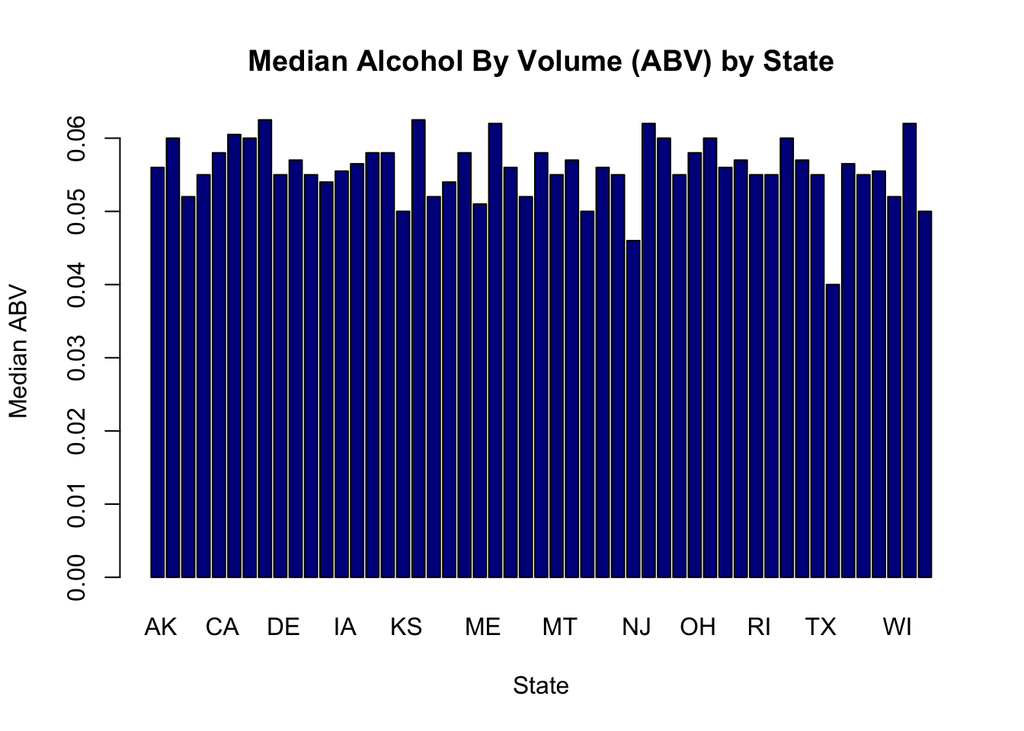

```r
MedianABV <- tapply(MergeBeerBreweries$ABV, MergeBeerBreweries$State, MedianBeerStat)
barplot(MedianABV, main="Median Alcohol By Volume (ABV) by State", xlab="State", ylab="Median ABV", col="darkblue")
```

```r
tapply(MergeBeerBreweries$IBU, MergeBeerBreweries$State, MedianBeerStat)
```

```
##   AK   AL   AR   AZ   CA   CO   CT   DC   DE   FL   GA   HI   IA   ID   IL
## 46.0 43.0 39.0 20.5 42.0 40.0 29.0 47.5 52.0 55.0 55.0 22.5 26.0 39.0 30.0
##   IN   KS   KY   LA   MA   MD   ME   MI   MN   MO   MS   MT   NC   ND   NE
## 33.0 20.0 31.5 31.5 35.0 29.0 61.0 35.0 44.5 24.0 45.0 40.0 33.5 32.0 35.0
##   NH   NJ   NM   NV   NY   OH   OK   OR   PA   RI   SC   SD   TN   TX   UT
## 48.5 34.5 51.0 41.0 47.0 40.0 35.0 40.0 30.0 24.0 30.0   NA 37.0 33.0 34.0
##   VA   VT   WA   WI   WV   WY
## 42.0 30.0 38.0 19.0 57.5 21.0
```

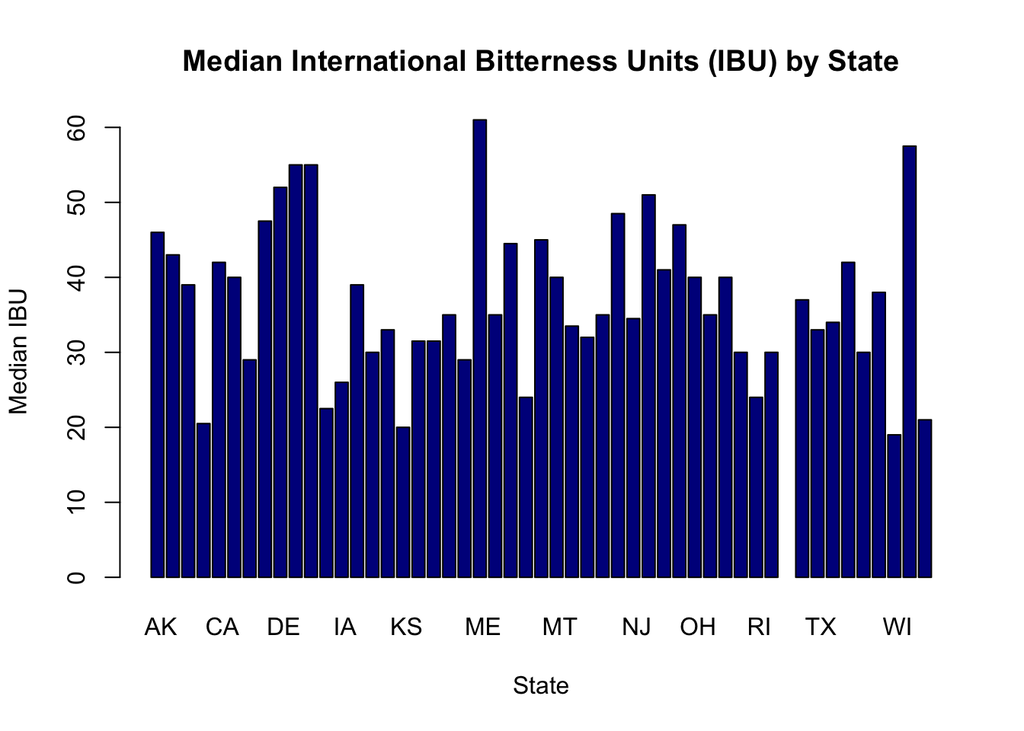

```r
MedianIBU <- tapply(MergeBeerBreweries$IBU, MergeBeerBreweries$State, MedianBeerStat)
barplot(MedianIBU, main="Median International Bitterness Units (IBU) by State", xlab="State", ylab="Median IBU", col="darkblue")
```

## 5. Which state has the maximum alcoholic (ABV) beer? Which state has the most bitter (IBU) beer?

#### Colorado has the maximum alcoholic (ABV) beer “Lee Hill Series Vol. 5 - Belgian Style Quadrupel Ale”, in terms of individual beers, while Oregon has the most bitter beer “Bitter Bitch Imperial IPA”, in terms of individual beers.

#### Using the median ABV and IBU data respectivly, Washington, DC and Kentucky are tied with the highest median alcoholic beer (ABV 0.0625), while Maine has the highest median bitterness (IBU 61).

```r
MergeBeerBreweries[which.max(MergeBeerBreweries$ABV),]
```

```
##     Brewery_ID                                            Beer_Name
## 375         52 Lee Hill Series Vol. 5 - Belgian Style Quadrupel Ale
##     Beer_ID   ABV IBU            Style Ounces Brew_ID
## 375    2565 0.128  NA Quadrupel (Quad)   19.2      52
##                Brewery_Name    City State
## 375 Upslope Brewing Company Boulder    CO
```

```r
MergeBeerBreweries[which.max(MergeBeerBreweries$IBU),]
```

```
##      Brewery_ID                 Beer_Name Beer_ID   ABV IBU
## 1857        375 Bitter Bitch Imperial IPA     980 0.082 138
##                               Style Ounces Brew_ID            Brewery_Name
## 1857 American Double / Imperial IPA     12     375 Astoria Brewing Company
##         City State
## 1857 Astoria    OR
```

```r
which.max(MedianABV)
```

```
##  DC
##   8
```

```r
MedianABV[c(8,18)]
```

```
##     DC     KY
## 0.0625 0.0625
```

```r
which.max(MedianIBU)
```

```
##  ME
##  22
```

```r
MedianIBU[22]
```

```
##  ME
##  61
```

## 6. Summary statistics for the ABV variable.

```r
summary(MergeBeerBreweries$ABV)
```

```
##    Min. 1st Qu.  Median    Mean 3rd Qu.    Max.    NA's
## 0.00100 0.05000 0.05600 0.05977 0.06700 0.12800      62
```

## 7. Is there an apparent relationship between the bitterness of the beer and its alcoholic content? Draw a scatter plot.

#### There appears to be a slight relationship between ABV and IBU (R^2 = 0.4493).

#### The regression equation is (IBU = -34.1 + 1282*ABV)

#### For every 0.01 point increase in ABV, IBU increases by ~12.82.

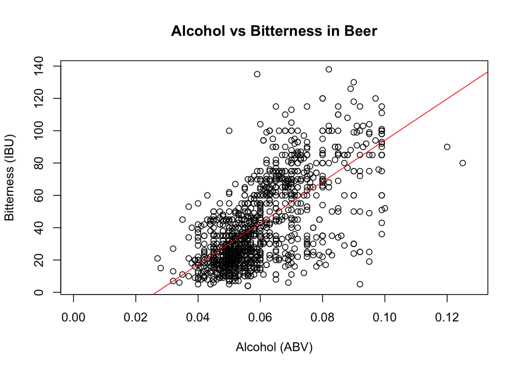

```r
attach(MergeBeerBreweries)
plot(ABV, IBU, main="Alcohol vs Bitterness in Beer", xlab="Alcohol (ABV)", ylab="Bitterness (IBU)")
abline(lm(IBU~ABV), col="red") # regression line (IBU~ABV)
```

```r
relation <- lm(IBU~ABV)
print(summary(relation))
```

```
##
## Call:
## lm(formula = IBU ~ ABV)
##
## Residuals:
##     Min      1Q  Median      3Q     Max
## -78.849 -11.977  -0.721  13.997  93.458
##
## Coefficients:
##             Estimate Std. Error t value Pr(>|t|)
## (Intercept)  -34.099      2.326  -14.66   <2e-16 ***
## ABV         1282.037     37.860   33.86   <2e-16 ***
## ---
## Signif. codes:  0 '***' 0.001 '**' 0.01 '*' 0.05 '.' 0.1 ' ' 1
##
## Residual standard error: 19.26 on 1403 degrees of freedom
##   (1005 observations deleted due to missingness)
## Multiple R-squared:  0.4497, Adjusted R-squared:  0.4493
## F-statistic:  1147 on 1 and 1403 DF,  p-value: < 2.2e-16
```